# Getting Started with airqualitytr

## Introduction

**airqualitytr** provides easy access to air quality monitoring data from the Turkish Ministry of Environment, Urbanization and Climate Change (See: https://sim.csb.gov.tr/). This package enables researchers, analysts, and policymakers to download and analyze environmental data across Turkey’s extensive network of monitoring stations.

### What You Can Do

- Download hourly or daily air quality measurements
- Access data from 300+ monitoring stations across 81 provinces
- Retrieve multiple pollutants: PM10, PM2.5, SO2, CO, NO2, NOX, NO, O3
- Download historical data with automatic chunking
- Perform bulk downloads with optional parallel processing

## Installation

Install the development version from GitHub:

```r
# Install pak if not already installed
if (!requireNamespace("pak", quietly = TRUE)) {
  install.packages("pak")
}

# Install airqualitytr
pak::pak("emraher/airqualitytr")
```

Load the package:

```r
library(airqualitytr)
library(dplyr)
```

```r
library(ggplot2)
library(lubridate)
library(purrr)
```

## Quick Start: Your First Download

Let’s download some air quality data in three simple steps:

### Step 1: Find a Station

First, explore available stations:

```r
# Get all available stations
stations <- list_stations()

# Glimpse stations
glimpse(stations)
```

```
#> Rows: 351
#> Columns: 20
#> $ station_id         <chr> "468478b7-ace5-4bd3-b89a-a9c1c2e53080", "9a381f61-6…
#> $ station_name       <chr> "Adana - Çatalan", "Adana - Çukurova", "Adana - Doğ…
#> $ city_id            <chr> "fddbbf7e-b853-431e-89d3-3522264e9383", "fddbbf7e-b…
#> $ city_name          <chr> "Adana", "Adana", "Adana", "Adana", "Adana", "Adana…
#> $ town_id            <chr> "f2310230-4df0-4957-8264-3910365c5d54", "f2c0daca-d…
#> $ location           <chr> "POINT (35.262032 37.18634800000001)", "POINT (35.2…
#> $ station_sub_type   <int> 1, 23, 1, 1, 1, 23, 2, 3, 1, 23, 1, 1, 1, 1, 1, 1, …
#> $ company_id         <chr> "59583087-1b69-4ea4-aef6-e492bf795391", "59583087-1…
#> $ company_id_name    <chr> "Akdeniz THM", "Akdeniz THM", "Akdeniz THM", "Akden…
#> $ station_group      <int> 5, 5, 5, 5, 5, 5, 5, 5, 1, 8, 8, 8, 7, 7, 7, 8, 2, …
#> $ station_group_name <chr> "Akdeniz THM", "Akdeniz THM", "Akdeniz THM", "Akden…
#> $ sector_code        <int> 1, 1, 1, 1, 1, 1, 1, 1, 1, 1, 1, 1, 1, 1, 1, 1, 1, …
#> $ sector_code_name   <chr> "Bakanlık", "Bakanlık", "Bakanlık", "Bakanlık", "Ba…
#> $ basin_id           <lgl> NA, NA, NA, NA, NA, NA, NA, NA, NA, NA, NA, NA, NA,…
#> $ data_periods       <int> 56, 56, 56, 56, 56, 56, 56, 56, 56, 56, 56, 56, 56,…
#> $ source_type        <int> 1003, 1000, 1003, 1000, 1000, 1000, 1001, 1002, 100…
#> $ source_type_name   <chr> "Arka Plan", "Isınma", "Arka Plan", "Isınma", "Isın…
#> $ area_type          <int> 2000, 2001, 2000, 2001, 2001, 2001, 2001, 2001, 200…
#> $ area_type_name     <chr> "Kırsal", "Kentsel", "Kırsal", "Kentsel", "Kentsel"…
#> $ is_portable        <lgl> FALSE, FALSE, FALSE, FALSE, FALSE, FALSE, FALSE, FA…
```

The station data includes:

- `station_id`: Unique identifier (UUID format)
- `station_name`: Human-readable station name
- `city_id`: City identifier
- `city_name`: City name
- Additional metadata: area type, company info, etc.

**Tip:** Filter stations by city or name:

```r
# Find stations in Ankara
ankara_stations <- stations |>
  filter(grepl("Ankara", city_name, ignore.case = TRUE))

glimpse(ankara_stations)
```

```
#> Rows: 19
#> Columns: 20
#> $ station_id         <chr> "251a7ea1-e3ff-4b2f-a4d2-1231118f83fa", "fcdb32a0-2…
#> $ station_name       <chr> "Ankara - Bahçelievler", "Ankara - Batıkent", "Anka…
#> $ city_id            <chr> "8dbbe10c-b2c5-44c1-bb3e-90be45aee744", "8dbbe10c-b…
#> $ city_name          <chr> "Ankara", "Ankara", "Ankara", "Ankara", "Ankara", "…
#> $ town_id            <chr> "d13efa96-79af-40ca-a713-b402387f9e8e", "5308eac7-5…
#> $ location           <chr> "POINT (32.822920238410219 39.9183612568786)", "POI…
#> $ station_sub_type   <int> 1, 1, 1, 1, 1, 1, 1, 1, 1, 3, 1, 1, 1, 1, 4, 1, 55,…
#> $ company_id         <chr> "8bde8b09-2809-4e66-923c-9b2269bc492c", "8bde8b09-2…
#> $ company_id_name    <chr> "Kuzey İç Anadolu THM", "Kuzey İç Anadolu THM", "Ku…
#> $ station_group      <int> 3, 3, 3, 3, 3, 3, 3, 3, 3, 3, 3, 3, 3, 3, 3, 3, 3, …
#> $ station_group_name <chr> "Kuzey İç Anadolu THM", "Kuzey İç Anadolu THM", "Ku…
#> $ sector_code        <int> 1, 1, 1, 1, 1, 1, 1, 1, 1, 1, 1, 1, 1, 1, 1, 1, 1, …
#> $ sector_code_name   <chr> "Bakanlık", "Bakanlık", "Bakanlık", "Bakanlık", "Ba…
#> $ basin_id           <lgl> NA, NA, NA, NA, NA, NA, NA, NA, NA, NA, NA, NA, NA,…
#> $ data_periods       <int> 56, 56, 56, 56, 56, 56, 56, 56, 56, 56, 56, 56, 56,…
#> $ source_type        <int> 1000, 1000, 1000, 1000, 1000, 1000, 1000, 1000, 100…
#> $ source_type_name   <chr> "Isınma", "Isınma", "Isınma", "Isınma", "Isınma", "…
#> $ area_type          <int> 2001, 2001, 2001, 2001, 2001, 2001, 2002, 2001, 200…
#> $ area_type_name     <chr> "Kentsel", "Kentsel", "Kentsel", "Kentsel", "Kentse…
#> $ is_portable        <lgl> FALSE, FALSE, FALSE, FALSE, FALSE, FALSE, FALSE, FA…
```

```r
# Find a specific station
selected_station <- stations |>
  filter(grepl("Sıhhıye", station_name, ignore.case = TRUE)) |>
  slice(1)

glimpse(selected_station)
```

```
#> Rows: 1
#> Columns: 20
#> $ station_id         <chr> "ed5b48d0-14c4-47a4-8ad1-b5db53ae72c9"
#> $ station_name       <chr> "Ankara - Sıhhıye"
#> $ city_id            <chr> "8dbbe10c-b2c5-44c1-bb3e-90be45aee744"
#> $ city_name          <chr> "Ankara"
#> $ town_id            <chr> "d13efa96-79af-40ca-a713-b402387f9e8e"
#> $ location           <chr> "POINT (32.8594022278403 39.927251825508819)"
#> $ station_sub_type   <int> 1
#> $ company_id         <chr> "8bde8b09-2809-4e66-923c-9b2269bc492c"
#> $ company_id_name    <chr> "Kuzey İç Anadolu THM"
#> $ station_group      <int> 3
#> $ station_group_name <chr> "Kuzey İç Anadolu THM"
#> $ sector_code        <int> 1
#> $ sector_code_name   <chr> "Bakanlık"
#> $ basin_id           <lgl> NA
#> $ data_periods       <int> 56
#> $ source_type        <int> 1001
#> $ source_type_name   <chr> "Trafik"
#> $ area_type          <int> 2001
#> $ area_type_name     <chr> "Kentsel"
#> $ is_portable        <lgl> FALSE
```

```r
station_id <- selected_station$station_id
```

### Step 2: Choose Your Parameters

See what pollutants are available:

```r
# List available parameters
(parameters <- list_parameters())
```

```
#> # A tibble: 8 × 2
#>   id    name
#>   <chr> <chr>
#> 1 PM10  PM10
#> 2 PM25  PM 2.5
#> 3 SO2   SO2
#> 4 CO    CO
#> 5 NO2   NO2
#> 6 NOX   NOX
#> 7 NO    NO
#> 8 O3    O3
```

Available parameters include:

- **PM10**: Particulate matter (≤10 μm)
- **PM2.5**: Fine particulate matter (≤2.5 μm)
- **SO2**: Sulfur dioxide
- **CO**: Carbon monoxide
- **NO2**: Nitrogen dioxide
- **NOX**: Nitrogen oxides
- **NO**: Nitric oxide
- **O3**: Ozone

### Step 3: Download Data

Now download air quality measurements:

```r
# Download one month of hourly PM10 data
data <- download_air_quality_data(
  station_id = station_id,
  parameters = c("PM10"),
  start_datetime = "2025-03-01 00:00",
  end_datetime = "2025-03-31 23:59",
  frequency = "hourly"
)

# View the results
glimpse(data)
```

```
#> Rows: 744
#> Columns: 23
#> $ time               <dttm> 2025-03-01 00:00:00, 2025-03-01 01:00:00, 2025-03-…
#> $ station_id         <chr> "ed5b48d0-14c4-47a4-8ad1-b5db53ae72c9", "ed5b48d0-1…
#> $ station_name       <chr> "Ankara - Sıhhıye", "Ankara - Sıhhıye", "Ankara - S…
#> $ city_id            <chr> "8dbbe10c-b2c5-44c1-bb3e-90be45aee744", "8dbbe10c-b…
#> $ city_name          <chr> "Ankara", "Ankara", "Ankara", "Ankara", "Ankara", "…
#> $ town_id            <chr> "d13efa96-79af-40ca-a713-b402387f9e8e", "d13efa96-7…
#> $ location           <chr> "POINT (32.8594022278403 39.927251825508819)", "POI…
#> $ station_sub_type   <int> 1, 1, 1, 1, 1, 1, 1, 1, 1, 1, 1, 1, 1, 1, 1, 1, 1, …
#> $ company_id         <chr> "8bde8b09-2809-4e66-923c-9b2269bc492c", "8bde8b09-2…
#> $ company_id_name    <chr> "Kuzey İç Anadolu THM", "Kuzey İç Anadolu THM", "Ku…
#> $ station_group      <int> 3, 3, 3, 3, 3, 3, 3, 3, 3, 3, 3, 3, 3, 3, 3, 3, 3, …
#> $ station_group_name <chr> "Kuzey İç Anadolu THM", "Kuzey İç Anadolu THM", "Ku…
#> $ sector_code        <int> 1, 1, 1, 1, 1, 1, 1, 1, 1, 1, 1, 1, 1, 1, 1, 1, 1, …
#> $ sector_code_name   <chr> "Bakanlık", "Bakanlık", "Bakanlık", "Bakanlık", "Ba…
#> $ basin_id           <lgl> NA, NA, NA, NA, NA, NA, NA, NA, NA, NA, NA, NA, NA,…
#> $ data_periods       <int> 56, 56, 56, 56, 56, 56, 56, 56, 56, 56, 56, 56, 56,…
#> $ source_type        <int> 1001, 1001, 1001, 1001, 1001, 1001, 1001, 1001, 100…
#> $ source_type_name   <chr> "Trafik", "Trafik", "Trafik", "Trafik", "Trafik", "…
#> $ area_type          <int> 2001, 2001, 2001, 2001, 2001, 2001, 2001, 2001, 200…
#> $ area_type_name     <chr> "Kentsel", "Kentsel", "Kentsel", "Kentsel", "Kentse…
#> $ is_portable        <lgl> FALSE, FALSE, FALSE, FALSE, FALSE, FALSE, FALSE, FA…
#> $ parameter          <chr> "PM10", "PM10", "PM10", "PM10", "PM10", "PM10", "PM…
#> $ value              <dbl> 56.92, 53.48, 51.67, 49.45, 49.59, 51.92, 40.99, 44…
```

The resulting data frame contains:

- `time`: POSIXct timestamp (UTC timezone)
- `station_id`: Station identifier
- `station_name`: Station name
- `city_name`: City name
- `parameter`: Pollutant name
- `value`: Measurement value
- Additional metadata columns

## Working with Multiple Parameters

Download multiple pollutants simultaneously:

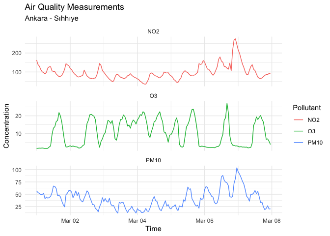

```r
# Download PM10, NO2, and O3
multi_param_data <- download_air_quality_data(
  station_id = station_id,
  parameters = c("PM10", "NO2", "O3"),
  start_datetime = "2025-03-01 00:00",
  end_datetime = "2025-03-07 23:59",
  frequency = "hourly"
)

# Data is in long format - easy to analyze and plot
ggplot(multi_param_data, aes(x = time, y = value, color = parameter)) +
  geom_line() +
  facet_wrap(~parameter, scales = "free_y", ncol = 1) +
  theme_minimal() +
  labs(
    title = "Air Quality Measurements",
    subtitle = unique(multi_param_data$station_name),
    x = "Time",
    y = "Concentration",
    color = "Pollutant"
  )
```

## Daily vs. Hourly Data

Choose the appropriate frequency for your analysis:

```r
# Hourly data - more detail, larger datasets
hourly_data <- download_air_quality_data(
  station_id = station_id,
  parameters = c("PM10"),
  start_datetime = "2025-03-01 00:00",
  end_datetime = "2025-03-07 23:59",
  frequency = "hourly"
)

# Daily data - aggregated, smaller datasets
# Note: Use longer date range for daily data as it aggregates measurements
daily_data <- download_air_quality_data(
  station_id = station_id,
  parameters = c("PM10"),
  start_datetime = "2025-03-01 00:00",
  end_datetime = "2025-03-31 23:59",
  frequency = "daily"
)

# Compare sizes
nrow(hourly_data) # ~168 rows (7 days * 24 hours)
```

```
#> [1] 168
```

```r
nrow(daily_data) # ~31 rows (31 days)
```

```
#> [1] 31
```

## Exploring Available Data

### List Cities

See all provinces with monitoring stations:

```r
(cities <- list_cities())
```

```
#> # A tibble: 81 × 2
#>    city_id                              city_name
#>    <chr>                                <chr>
#>  1 fddbbf7e-b853-431e-89d3-3522264e9383 Adana
#>  2 50cd2278-5573-4069-b7a9-2aacaf11431a Adıyaman
#>  3 c9b19ecd-1ffc-4616-ab1a-790aaf539bfe Afyonkarahisar
#>  4 12b12d2f-1fd1-41a5-9142-7fe31e5134e3 Ağrı
#>  5 0d977726-b21e-4ef8-b852-e659286f1778 Aksaray
#>  6 b1bd61cf-1528-4a3e-9b45-c30cbf223035 Amasya
#>  7 8dbbe10c-b2c5-44c1-bb3e-90be45aee744 Ankara
#>  8 c414e607-cb0f-4226-997c-62a9eb563b2b Antalya
#>  9 d40a8bdb-1402-43e6-9e92-1f1c8484632c Ardahan
#> 10 a0da922a-ff51-4e7d-9f75-7fe44217d725 Artvin
#> # ℹ 71 more rows
```

```r
# Count stations per city
stations_per_city <- stations |>
  count(city_name) |>
  arrange(desc(n))

stations_per_city
```

```
#> # A tibble: 81 × 2
#>    city_name     n
#>    <chr>     <int>
#>  1 İstanbul     40
#>  2 İzmir        25
#>  3 Ankara       19
#>  4 Kocaeli      12
#>  5 Konya        12
#>  6 Bursa         9
#>  7 Manisa        9
#>  8 Adana         8
#>  9 Antalya       8
#> 10 Zonguldak     8
#> # ℹ 71 more rows
```

### Filter Stations

Find stations matching specific criteria:

```r
# Stations in major cities
major_cities <- c("İstanbul", "Ankara", "İzmir")

(major_city_stations <- stations |>
  filter(city_name %in% major_cities))
```

```
#> # A tibble: 84 × 20
#>    station_id   station_name city_id city_name town_id location station_sub_type
#>    <chr>        <chr>        <chr>   <chr>     <chr>   <chr>               <int>
#>  1 251a7ea1-e3… Ankara - Ba… 8dbbe1… Ankara    d13efa… POINT (…                1
#>  2 fcdb32a0-24… Ankara - Ba… 8dbbe1… Ankara    5308ea… POINT (…                1
#>  3 eec16797-8c… Ankara - Ça… 8dbbe1… Ankara    d13efa… POINT (…                1
#>  4 0ef764db-fc… Ankara - De… 8dbbe1… Ankara    5308ea… POINT (…                1
#>  5 b6cee520-e7… Ankara - Et… 8dbbe1… Ankara    3f3653… POINT (…                1
#>  6 a24eb747-ac… Ankara - Et… 8dbbe1… Ankara    5308ea… POINT (…                1
#>  7 073ba16f-a5… Ankara - Ka… 8dbbe1… Ankara    422c13… POINT (…                1
#>  8 c960495f-43… Ankara - Ke… 8dbbe1… Ankara    908bf8… POINT (…                1
#>  9 ec35e67b-2f… Ankara - Ma… 8dbbe1… Ankara    d13efa… POINT (…                1
#> 10 4ef4bba3-8a… Ankara - Os… 8dbbe1… Ankara    5308ea… POINT (…                3
#> # ℹ 74 more rows
#> # ℹ 13 more variables: company_id <chr>, company_id_name <chr>,
#> #   station_group <int>, station_group_name <chr>, sector_code <int>,
#> #   sector_code_name <chr>, basin_id <lgl>, data_periods <int>,
#> #   source_type <int>, source_type_name <chr>, area_type <int>,
#> #   area_type_name <chr>, is_portable <lgl>
```

```r
# Stations with specific names
(traffic_stations <- stations |>
  filter(grepl("Trafik|Traffic", station_name, ignore.case = TRUE)))
```

```
#> # A tibble: 11 × 20
#>    station_id   station_name city_id city_name town_id location station_sub_type
#>    <chr>        <chr>        <chr>   <chr>     <chr>   <chr>               <int>
#>  1 a28335de-f8… Antalya - T… c414e6… Antalya   16a79f… POINT (…                2
#>  2 8bc851d6-0d… Aydın - Tra… ecae8e… Aydın     9aa38e… POINT (…                1
#>  3 eb3da119-cc… Denizli - T… 72da23… Denizli   b47e9b… POINT (…                1
#>  4 4a5df435-f0… Erzincan - … c182e0… Erzincan  b83273… POINT (…                1
#>  5 6b07d8e7-0d… Kars - Traf… 3c3a0c… Kars      f71b99… POINT (…                1
#>  6 410336ce-0c… Kayseri - T… 2ad8ad… Kayseri   b42c48… POINT (…                1
#>  7 248d338b-6f… Konya - Tra… 08f472… Konya     2388f7… POINT (…                2
#>  8 06bf6e3e-72… Mardin - Tr… fca109… Mardin    8eb0c0… POINT (…             1001
#>  9 8ed105e7-26… Muğla - Tra… 82a3cf… Muğla     489d57… POINT (…                2
#> 10 99cf689e-1e… Uşak-Trafik  212810… Uşak      ff6fdf… POINT (…                2
#> 11 7058210e-a4… Zonguldak -… 24b802… Zonguldak 6af7b6… POINT (…                1
#> # ℹ 13 more variables: company_id <chr>, company_id_name <chr>,
#> #   station_group <int>, station_group_name <chr>, sector_code <int>,
#> #   sector_code_name <chr>, basin_id <lgl>, data_periods <int>,
#> #   source_type <int>, source_type_name <chr>, area_type <int>,
#> #   area_type_name <chr>, is_portable <lgl>
```

```r
# Get unique station types if available in metadata
if ("area_type_name" %in% names(stations)) {
  table(stations$area_type_name)
}
```

```
#>
#> Kent Çevresi      Kentsel       Kırsal
#>           45          283           23
```

## Understanding the Data Structure

### Column Naming

All columns use **snake_case** format for consistency:

This makes data manipulation easier and more predictable.

### Time Zones

All timestamps are in **UTC**:

```r
# Check timezone
attr(data$time, "tzone") # "UTC"
```

```
#> [1] "UTC"
```

```r
# Convert to Turkey time (UTC+3) if needed
data_turkey_time <- data |>
  mutate(time_local = with_tz(time, tzone = "Europe/Istanbul"))
```

### Missing Values

Missing measurements appear as `NA` in the `value` column:

```r
# Check for missing values
summary(data$value)
```

```
#>    Min. 1st Qu.  Median    Mean 3rd Qu.    Max.    NA's
#>    4.15   24.88   41.61   43.08   58.56  124.38       1
```

```r
# Count missing by parameter
data |>
  group_by(parameter) |>
  summarize(
    total = n(),
    missing = sum(is.na(value)),
    pct_missing = round(100 * missing / total, 1)
  )
```

```
#> # A tibble: 1 × 4
#>   parameter total missing pct_missing
#>   <chr>     <int>   <int>       <dbl>
#> 1 PM10        744       1         0.1
```

```r
# Remove missing values for analysis
clean_data <- data |>
  filter(!is.na(value))
```

## Error Handling and Validation

The package validates your inputs and provides helpful error messages:

```r
# Invalid station ID format
try(
  download_air_quality_data(
    station_id = "invalid-id",
    parameters = c("PM10"),
    start_datetime = "2025-03-01 00:00",
    end_datetime = "2025-03-31 23:59"
  )
)
```

```
#> Error : Invalid station_id format. Expected UUID format (8-4-4-4-12 hex digits).
#>   - Example: '468478b7-ace5-4bd3-b89a-a9c1c2e53080'
#>   - Received: 'invalid-id'
#>   - Use list_stations() to get valid station IDs.
```

```r
# Error: Invalid station_id format. Must be a valid UUID.

# Invalid date range
try(
  download_air_quality_data(
    station_id = station_id,
    parameters = c("PM10"),
    start_datetime = "2025-03-31 00:00",
    end_datetime = "2025-03-01 00:00" # End before start!
  )
)
```

```
#> Error : start_datetime must be before end_datetime.
#>   - Start: 2025-03-31 00:00
#>   - End: 2025-03-01 00:00
#>   - Please ensure the start date comes before the end date.
```

```r
# Error: start_datetime must be before end_datetime

# Invalid parameter
try(
  download_air_quality_data(
    station_id = station_id,
    parameters = c("INVALID_PARAM"),
    start_datetime = "2025-03-01 00:00",
    end_datetime = "2025-03-31 23:59"
  )
)
```

```
#> Error : Invalid parameter(s): INVALID_PARAM
#>   - Valid parameters are: PM10, PM25, SO2, CO, NO2, NOX, NO, O3
#>   - Use list_parameters() to see all available parameters with descriptions.
```

```r
# Error with suggestions for valid parameters
```

## Common Workflows

### Workflow 1: Compare Multiple Stations

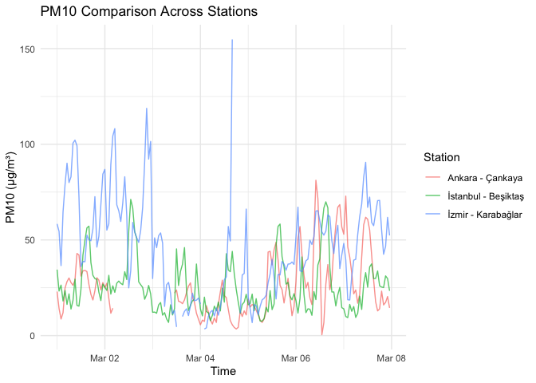

```r
# Select 3 stations from different cities
comparison_stations <- stations |>
  filter(station_name %in% c("İstanbul - Beşiktaş", "Ankara - Çankaya", "İzmir - Karabağlar")) |>
  group_by(city_name) |>
  slice_sample(n = 1) |>
  ungroup()

# Download data for each station
comparison_data <- map_dfr(
  comparison_stations$station_id,
  ~ download_air_quality_data(
    station_id = .x,
    parameters = c("PM10"),
    start_datetime = "2025-03-01 00:00",
    end_datetime = "2025-03-07 23:59",
    frequency = "hourly"
  )
)

# Compare stations
ggplot(comparison_data, aes(x = time, y = value, color = station_name)) +
  geom_line(alpha = 0.7) +
  theme_minimal() +
  labs(
    title = "PM10 Comparison Across Stations",
    x = "Time",
    y = "PM10 (μg/m³)",
    color = "Station"
  )
```

### Workflow 2: Calculate Daily Statistics

```r
# Download hourly data
hourly <- download_air_quality_data(
  station_id = station_id,
  parameters = c("PM10"),
  start_datetime = "2025-03-01 00:00",
  end_datetime = "2025-03-31 23:59",
  frequency = "hourly"
)

# Calculate daily statistics
daily_stats <- hourly |>
  filter(!is.na(value)) |>
  mutate(date = as.Date(time)) |>
  group_by(date, station_name, parameter) |>
  summarize(
    mean = mean(value),
    min = min(value),
    max = max(value),
    sd = sd(value),
    n = n(),
    .groups = "drop"
  )

daily_stats
```

```
#> # A tibble: 31 × 8
#>    date       station_name     parameter  mean   min   max    sd     n
#>    <date>     <chr>            <chr>     <dbl> <dbl> <dbl> <dbl> <int>
#>  1 2025-03-01 Ankara - Sıhhıye PM10       48.6  24.6  66.7 10.0     24
#>  2 2025-03-02 Ankara - Sıhhıye PM10       40.3  14.5  57.5 12.7     24
#>  3 2025-03-03 Ankara - Sıhhıye PM10       25.8  11.8  41.8  9.26    24
#>  4 2025-03-04 Ankara - Sıhhıye PM10       24.5  12.9  45.4  9.16    24
#>  5 2025-03-05 Ankara - Sıhhıye PM10       34.5  16.8  64.7 13.5     24
#>  6 2025-03-06 Ankara - Sıhhıye PM10       60.3  30.6 104.  19.3     24
#>  7 2025-03-07 Ankara - Sıhhıye PM10       48.4  18.6  95.4 22.6     24
#>  8 2025-03-08 Ankara - Sıhhıye PM10       25.8  16.6  44.1  7.55    24
#>  9 2025-03-09 Ankara - Sıhhıye PM10       34.9  12.4  55.9 12.7     24
#> 10 2025-03-10 Ankara - Sıhhıye PM10       50.8  30.9 122.  18.6     23
#> # ℹ 21 more rows
```

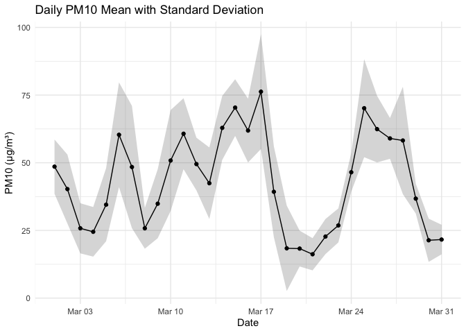

```r
# Plot with error bars
ggplot(daily_stats, aes(x = date, y = mean)) +
  geom_ribbon(aes(ymin = mean - sd, ymax = mean + sd), alpha = 0.2) +
  geom_line() +
  geom_point() +
  theme_minimal() +
  labs(
    title = "Daily PM10 Mean with Standard Deviation",
    x = "Date",
    y = "PM10 (μg/m³)"
  )
```

### Workflow 3: Identify Peak Pollution Events

```r
# Download one month of hourly PM10 data
data <- download_air_quality_data(
  station_id = "ed5b48d0-14c4-47a4-8ad1-b5db53ae72c9",
  parameters = c("PM10"),
  start_datetime = "2025-03-01 00:00",
  end_datetime = "2025-03-31 23:59",
  frequency = "hourly"
)

# Find hours exceeding WHO guidelines (PM10 > 45 μg/m³ daily mean)
exceedances <- data |>
  filter(!is.na(value)) |>
  mutate(date = as.Date(time)) |>
  group_by(date, station_name) |>
  summarize(
    daily_mean = mean(value),
    daily_max = max(value),
    .groups = "drop"
  ) |>
  filter(daily_mean > 45)

exceedances
```

```
#> # A tibble: 15 × 4
#>    date       station_name     daily_mean daily_max
#>    <date>     <chr>                 <dbl>     <dbl>
#>  1 2025-03-01 Ankara - Sıhhıye       48.6      66.7
#>  2 2025-03-06 Ankara - Sıhhıye       60.3     104.
#>  3 2025-03-07 Ankara - Sıhhıye       48.4      95.4
#>  4 2025-03-10 Ankara - Sıhhıye       50.8     122.
#>  5 2025-03-11 Ankara - Sıhhıye       60.7      85.3
#>  6 2025-03-12 Ankara - Sıhhıye       49.5      62.6
#>  7 2025-03-14 Ankara - Sıhhıye       62.9      81.6
#>  8 2025-03-15 Ankara - Sıhhıye       70.4      85.4
#>  9 2025-03-16 Ankara - Sıhhıye       61.9      82.7
#> 10 2025-03-17 Ankara - Sıhhıye       76.3     124.
#> 11 2025-03-24 Ankara - Sıhhıye       46.5      62.5
#> 12 2025-03-25 Ankara - Sıhhıye       70.1     110.
#> 13 2025-03-26 Ankara - Sıhhıye       62.4      91.1
#> 14 2025-03-27 Ankara - Sıhhıye       59.0      68.7
#> 15 2025-03-28 Ankara - Sıhhıye       58.2      83.3
```

```r
# Percentage of days exceeding guidelines
pct_exceeding <- 100 * nrow(exceedances) / n_distinct(as.Date(data$time))
glue::glue("{scales::number(pct_exceeding, accuracy = 0.1)}% of days exceeded WHO PM10 guidelines\n")
```

```
#> 48.4% of days exceeded WHO PM10 guidelines
```

## Next Steps

Now that you’ve learned the basics, explore these advanced topics:

- **Parallel Processing** - Speed up bulk downloads
- **Long-term Data Collection** - Download years of historical data
- **Data Quality Assessment** - Check and clean your data

## Getting Help

If you encounter issues:

1. Check the **Troubleshooting** section in the README
2. Review function documentation: `?download_air_quality_data`
3. Report bugs: https://github.com/emraher/airqualitytr/issues

## Data Source and Citation

This package accesses data from the Turkish Ministry of Environment, Urbanization and Climate Change.

**Please check the official data policy at the Ministry’s website for:** - Data licensing terms - Citation requirements for publications - Usage restrictions and permissions

Always cite both the data source and this package in your research.